# Homework 1 Data Science I

Olivia Wagner

2019-09-14

```r
knitr::opts_chunk$set(echo = TRUE)
library(tidyverse)
```

## Problem 1

** Part 1 **

```r
# create individual columns based on specifcations #

column_1 = rnorm(8, mean = 0, sd = 1)

column_2 = (column_1 > 0)

column_3 = c("a", "b", "c", "d", "e", "f", "g", "h")

column_4 = factor(c('red', 'blue', 'purple', 'red', 'blue', 'purple', 'red', 'blue'))


# combine to create a data frame #


problem_1_df = data.frame(column_1, column_2, column_3, column_4, stringsAsFactors = FALSE)

print(problem_1_df)
```

```
##      column_1 column_2 column_3 column_4
## 1  0.74117121     TRUE        a      red
## 2 -0.03292625    FALSE        b     blue
## 3 -1.31792419    FALSE        c   purple
## 4  1.00987633     TRUE        d      red
## 5 -0.96950697    FALSE        e     blue
## 6  0.05595651     TRUE        f   purple
## 7  0.79764188     TRUE        g      red
## 8  0.71096225     TRUE        h     blue
```

```r
# Find the mean of each variable in the data frame #


mean(column_1)
```

```
## [1] 0.1244063
```

```r
mean(column_2)
```

```
## [1] 0.625
```

```r
mean(column_3)
```

```
## [1] NA
```

```r
mean(column_4)
```

```
## [1] NA
```

```r
# Try to adjust each column to be of type numeric #


as.numeric(column_2)
```

```
## [1] 1 0 0 1 0 1 1 1
```

```r
as.numeric(column_3)
```

```
## [1] NA NA NA NA NA NA NA NA
```

```r
as.numeric(column_4)
```

```
## [1] 3 1 2 3 1 2 3 1
```

I can take the mean of the first and second columns, or the numeric and logical variables. I cannot take the mean of the factor or character columns.

Using the as.numeric command I am able to convert the logical and factor variables to numeric, while I am unable to do so with the character variable. This explains the problem with computing the mean in the character varaible. Because R cannot assign numeric placeholder variables to characters, it is unable to compute a mean from the individual strings in the column.Though R can assign placeholder values to a factor variable, it is still unable to calculate a mean. Because a factor variable is multilayered categorical variable, R would be taking a mean of fixed values. The result would not be representative of anything meaningful.

** Part 2 **

```r
# Convert logical vector to numeric and multiply by the random sample vector #
column_2_numeric = as.numeric(column_2)
random_sample_numeric = column_1 * column_2_numeric

print(random_sample_numeric)
```

```
## [1] 0.74117121 0.00000000 0.00000000 1.00987633 0.00000000 0.05595651
## [7] 0.79764188 0.71096225
```

```r
# Convert the logical vector to factor and multiply by the random sample vector #
column_2_factor = as.factor(column_2)
random_sample_factor = column_1 * column_2_factor
print(random_sample_factor)
```

```
## [1] NA NA NA NA NA NA NA NA
```

```r
# Convert the logical vector to factor then to numeric, and multiply by the random sample vector #
column_2_factor_to_numeric = as.numeric(as.factor(column_2))
random_sample_factor_to_numeric = column_1 * column_2_factor_to_numeric

print(random_sample_factor_to_numeric)
```

```
## [1]  1.48234241 -0.03292625 -1.31792419  2.01975267 -0.96950697  0.11191302
## [7]  1.59528375  1.42192450
```

## Problem 2

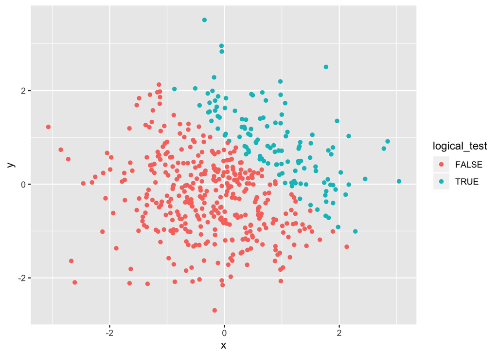

```r
x = rnorm(500, mean = 0, sd = 1)

y = rnorm(500, mean = 0, sd = 1)

logical_test = (x + y > 1)

numeric_test = as.numeric(logical_test)

factor_test = as.factor(logical_test)

problem_2_df = data.frame(x, y, logical_test, numeric_test,factor_test, stringsAsFactors = FALSE)


# descriptive statistics about the data frame #

rows = nrow(problem_2_df)
cols = ncol(problem_2_df)

mean = mean(x)
median = median(x)
sd = sd(x)

true = sum(logical_test, na.rm = TRUE)
false = (rows - true)
true_prop = (true/rows)


# Scatterplot of y vs. x, using logical variable coloring #

ggplot(data = problem_2_df) +
  geom_point(mapping = aes(x = x, y = y, color = logical_test))
```

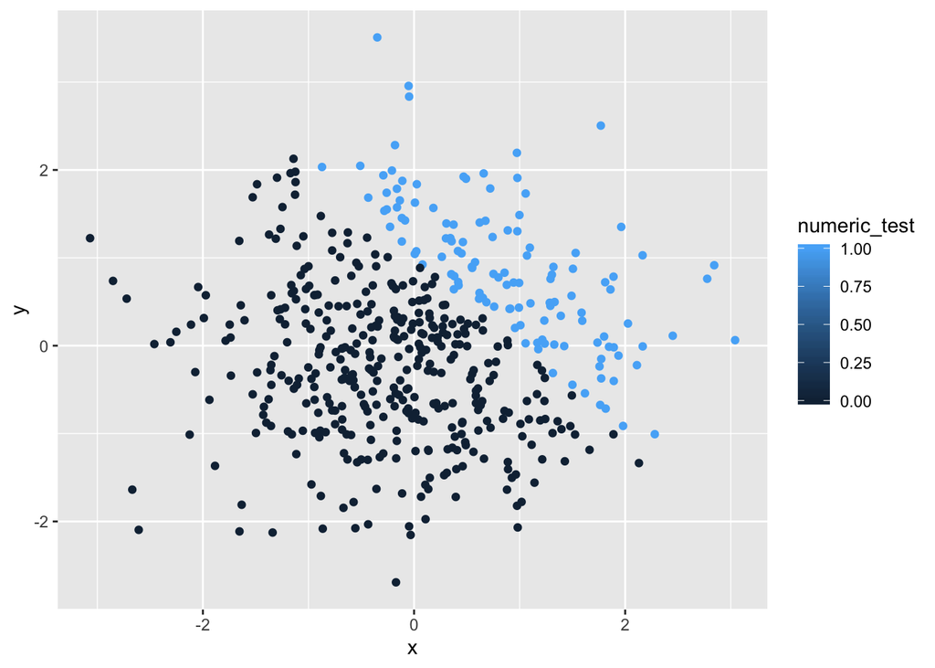

```r
# Save scatterplot to Project #

ggsave('XY_Scatterplot.pdf')
# Scatterplot of y vs. x, using numeric variable coloring #

ggplot(data = problem_2_df) +
  geom_point(mapping = aes(x = x, y = y, color = numeric_test))
```

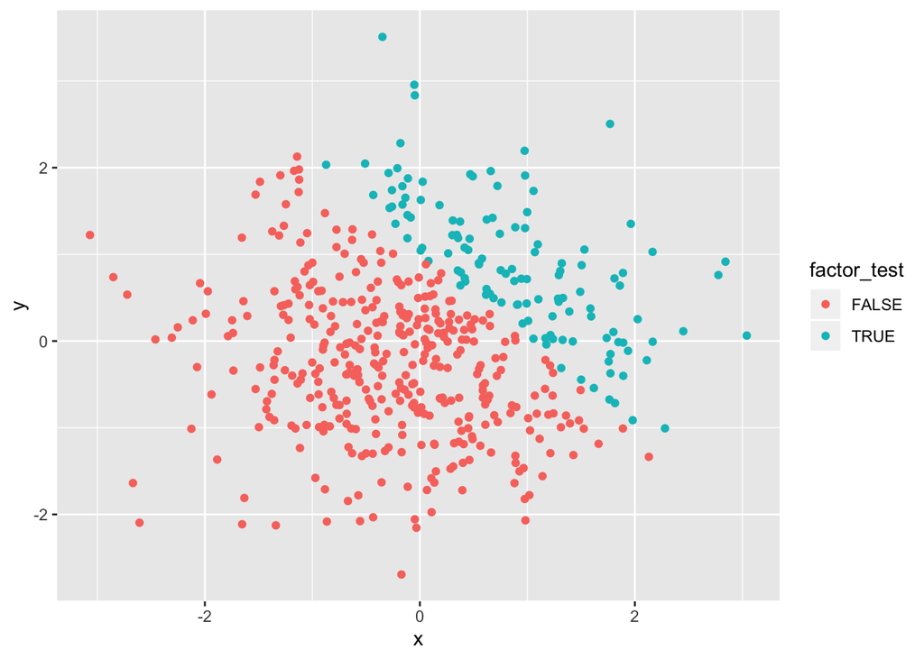

```r
# Scatterplot of y vs. x, using factor variable coloring #

ggplot(data = problem_2_df) +
  geom_point(mapping = aes(x = x, y = y, color = factor_test))
```

** Part 1 **

The data set is 5 wide and 500 long.

The mean of the column x is -0.0087043, the median of column x is -0.0392454 and standard deviation of column x is 1.0011259.

The proportion of cases for which the third column, logical_test, returns true is 0.248.

** Part 2 **

The color scale switches between factor and numeric variables. Because a factor is necessarily a integer, there is a distinct color per each integer. A numeric variable can take the value of any real number, so the color scale must be gradient to account for the infinite number of values between the maximum and minimum value.